# Project 3 - Data Analysis using R by Arturo Battinelli

This project is about the analysis of the data related to the Financial Contributions to 2012 Presidential Campaigns in the State of Massachusetts. The dataset has been downloaded from the Federal Election Commission’s website (http://www.fec.gov).

# Univariate Plots Section

### Initial analysis

Let’s run some basic commands to get an overview of the data

```r
names(ma2012)
```

```
##  [1] "cmte_id"           "cand_id"           "cand_nm"
##  [4] "contbr_nm"         "contbr_city"       "contbr_st"
##  [7] "contbr_zip"        "contbr_employer"   "contbr_occupation"
## [10] "contb_receipt_amt" "contb_receipt_dt"  "receipt_desc"
## [13] "memo_cd"           "memo_text"         "form_tp"
## [16] "file_num"          "tran_id"           "election_tp"
## [19] "contbr_zip_clean"  "zip"               "city"
## [22] "state"             "latitude"          "longitude"
## [25] "distance"          "cand_gender"       "cand_party"
## [28] "days_togo"
```

```r
length(ma2012)
```

```
## [1] 28
```

```r
nrow(ma2012)
```

```
## [1] 211303
```

```r
dim(ma2012)
```

```
## [1] 211303     28
```

```r
head(ma2012)
```

```
##     cmte_id   cand_id       cand_nm           contbr_nm contbr_city
## 1 C00431445 P80003338 Obama, Barack     HENN, CATHERINE   CAMBRIDGE
## 2 C00431445 P80003338 Obama, Barack      GREENE, JUDITH   WORCESTER
## 3 C00431445 P80003338 Obama, Barack MENDELSOHN, DAVID O      WESTON
## 4 C00431445 P80003338 Obama, Barack      WILLETT, JERRI      CONWAY
## 5 C00431445 P80003338 Obama, Barack       KRAUSZ, MARIE    WESTWOOD
## 6 C00431445 P80003338 Obama, Barack     OLMSTEAD, ANN M    AMESBURY
##   contbr_st contbr_zip                     contbr_employer
## 1        MA  021402707                        NOT EMPLOYED
## 2        MA  016091161                             RETIRED
## 3        MA      02493                                FEMA
## 4        MA  013419774 UNIVERSITY OF MASSACHUSETTS AMHERST
## 5        MA  020901123                             RETIRED
## 6        MA      01913                 RE/MAX ON THE RIVER
##    contbr_occupation contb_receipt_amt contb_receipt_dt receipt_desc
```

[output cut: 27 more lines]

```r
summary(ma2012)
```

```
##       cmte_id            cand_id
##  C00431445:168065   P80003338:168065
##  C00431171: 38672   P80003353: 38672
##  C00495820:  2553   P80000748:  2553
##  C00496034:   544   P20002721:   544
##  C00496497:   444   P60003654:   444
##  C00493692:   188   P20002523:   188
##  (Other)  :   837   (Other)  :   837
##                            cand_nm
##  Obama, Barack                 :168065
##  Romney, Mitt                  : 38672
##  Paul, Ron                     :  2553
##  Santorum, Rick                :   544
##  Gingrich, Newt                :   444
##  Roemer, Charles E. 'Buddy' III:   188
##  (Other)                       :   837
##                       contbr_nm          contbr_city     contbr_st
##  WHITESELL, JONATHAN D. MR.:   144   BOSTON    : 14250   MA:211303
##  HAJIR, JAMSHID            :   129   CAMBRIDGE : 14056
##  BAGAMPALLI, UDAY          :   118   BROOKLINE :  7240
##  CHECKET, CAITLIN          :   118   NEWTON    :  5677
##  CHIN, FONDA               :    95   LEXINGTON :  4253
##  SKINNER, BRIAN            :    94   SOMERVILLE:  3661
##  (Other)                   :210605   (Other)   :162166
##    contbr_zip                                   contbr_employer
##  02138  :  2291   RETIRED                               : 34410
##  02130  :  1486   SELF-EMPLOYED                         : 28689
##  02446  :  1371   NOT EMPLOYED                          : 13693
##  02139  :  1362   INFORMATION REQUESTED                 :  4652
##  02445  :  1149   INFORMATION REQUESTED PER BEST EFFORTS:  3718
##  02140  :  1037   (Other)                               :126085
##  (Other):202607   NA's                                  :    56
##  contbr_occupation  contb_receipt_amt contb_receipt_dt
##  RETIRED  : 38083   Min.   :-7500.0   Min.   :2008-04-02
##  ATTORNEY :  5939   1st Qu.:   25.0   1st Qu.:2012-06-27
##  PROFESSOR:  5715   Median :   50.0   Median :2012-09-11
##  PHYSICIAN:  5609   Mean   :  208.7   Mean   :2012-07-27
##  HOMEMAKER:  4727   3rd Qu.:  141.0   3rd Qu.:2012-10-17
##  (Other)  :151196   Max.   :20000.0   Max.   :2012-12-31
##  NA's     :    34
```

[output cut: 33 more lines]

```
##  Min.   :-74.71   Min.   :  0.000   Female:   294   Democrat   :168065
##  1st Qu.:-71.35   1st Qu.:  8.784   Male  :211009   Republican : 42860
##  Median :-71.15   Median : 20.934                   Libertarian:    76
##  Mean   :-71.29   Mean   : 38.901                   Tea        :   172
##  3rd Qu.:-71.07   3rd Qu.: 49.740                   Green      :   130
##  Max.   :-68.26   Max.   :341.613
##  NA's   :346      NA's   :346
##    days_togo
##  Min.   : -55.0
##  1st Qu.:  20.0
##  Median :  56.0
##  Mean   : 101.7
##  3rd Qu.: 132.0
##  Max.   :1679.0
##
```

```r
table(ma2012$cand_nm)
```

```
##
##              Bachmann, Michele                   Cain, Herman
##                            164                            172
##                 Gingrich, Newt                  Huntsman, Jon
##                            444                            177
##             Johnson, Gary Earl                  Obama, Barack
##                             76                         168065
##                      Paul, Ron              Pawlenty, Timothy
##                           2553                             62
##                    Perry, Rick Roemer, Charles E. 'Buddy' III
##                             56                            188
##                   Romney, Mitt                 Santorum, Rick
##                          38672                            544
##                    Stein, Jill
##                            130
```

```r
table(ma2012$cand_gender)
```

```
##
## Female   Male
##    294 211009
```

```r
table(ma2012$cand_party)
```

```
##
##    Democrat  Republican Libertarian         Tea       Green
##      168065       42860          76         172         130
```

```r
table(ma2012$election_tp)
```

```
##
##         G2008  G2012  O2012  P2008  P2012
##     12     17 115725    140     23  95386
```

```r
summary(ma2012$contb_receipt_amt)
```

```
##    Min. 1st Qu.  Median    Mean 3rd Qu.    Max.
## -7500.0    25.0    50.0   208.7   141.0 20000.0
```

```r
summary(ma2012$distance)
```

```
##    Min. 1st Qu.  Median    Mean 3rd Qu.    Max.    NA's
##   0.000   8.784  20.930  38.900  49.740 341.600     346
```

```r
summary(subset(ma2012, ma2012$contb_receipt_amt < 0))
```

```
##       cmte_id          cand_id                               cand_nm
##  C00431445:1411   P80003338:1411   Obama, Barack                 :1411
##  C00431171: 531   P80003353: 531   Romney, Mitt                  : 531
##  C00496497:  21   P60003654:  21   Gingrich, Newt                :  21
##  C00495820:  17   P80000748:  17   Paul, Ron                     :  17
##  C00493692:   6   P20002523:   6   Roemer, Charles E. 'Buddy' III:   6
##  C00494393:   5   P20002556:   5   Pawlenty, Timothy             :   5
##  (Other)  :   9   (Other)  :   9   (Other)                       :   9
##            contbr_nm       contbr_city   contbr_st   contbr_zip
##  CHARLES, FRANTZ:  29   BOSTON   : 244   MA:2000   02143  :  41
##  ADU, JOSEPH    :  18   CAMBRIDGE: 136             02155  :  41
##  SABOT, JUDITH  :  18   BROOKLINE:  84             02138  :  32
##  NAYLOR, RUTH   :  15   NEWTON   :  66             02118  :  22
##  RIVARD, DANIEL :  15   WESTON   :  60             01810  :  21
##  CANTOR, MURRAY :  12   WELLESLEY:  49             02478  :  19
##  (Other)        :1893   (Other)  :1361             (Other):1824
##                                contbr_employer
##                                        :1551
##  RETIRED                               :  83
##  SELF-EMPLOYED                         :  38
##  HOMEMAKER                             :  33
##  INFORMATION REQUESTED PER BEST EFFORTS:  22
##  DEDHAM/WEST ROXBURY WHLSALE TIRE AND A:  10
##  (Other)                               : 263
##                               contbr_occupation contb_receipt_amt
##                                        :1551    Min.   :-7500.00
##  RETIRED                               :  93    1st Qu.: -500.00
##  HOMEMAKER                             :  33    Median : -135.00
##  INFORMATION REQUESTED PER BEST EFFORTS:  20    Mean   : -590.05
##  ATTORNEY                              :  17    3rd Qu.:  -50.00
##  EXECUTIVE                             :  12    Max.   :   -0.12
##  (Other)                               : 274
##  contb_receipt_dt                            receipt_desc  memo_cd
##  Min.   :2011-04-15   Refund                       :1551    :1602
##  1st Qu.:2012-06-01   REDESIGNATION TO GENERAL     : 189   X: 398
##  Median :2012-10-08                                : 155
##  Mean   :2012-08-09   REATTRIBUTION TO SPOUSE      :  84
##  3rd Qu.:2012-11-15   REDESIGNATION TO PRIMARY DEBT:  14
##  Max.   :2012-12-31   REATTRIBUTED BELOW           :   4
##                       (Other)                      :   3
```

[output cut: 17 more lines]

```
##  Boston    : 230   Length:2000        Min.   :41.27   Min.   :-73.37
##  Cambridge : 139   Class :character   1st Qu.:42.28   1st Qu.:-71.29
##  Brookline :  88   Mode  :character   Median :42.35   Median :-71.14
##  Weston    :  60                      Mean   :42.32   Mean   :-71.28
##  Somerville:  51                      3rd Qu.:42.39   3rd Qu.:-71.07
##  Medford   :  48                      Max.   :42.85   Max.   :-69.97
##  (Other)   :1384
##     distance       cand_gender         cand_party     days_togo
##  Min.   :  0.000   Female:   2   Democrat   :1411   Min.   :-55.00
##  1st Qu.:  6.557   Male  :1998   Republican : 589   1st Qu.: -9.25
##  Median : 17.150                 Libertarian:   0   Median : 29.00
##  Mean   : 32.379                 Tea        :   0   Mean   : 88.53
##  3rd Qu.: 34.590                 Green      :   0   3rd Qu.:158.00
##  Max.   :190.719                                    Max.   :571.00
##
```

Let’s now check the cases where the city in the original dataset differs from the city coming from the join with the zipcodes dataset. As we can see, most of the differences are due to data quality issues, for example “Beverly” vs. “Beverly Farms”, “New Town” vs. “Newton”, “North Falmouth” vs. “N FALMOUTH” etc… Here below only the first 50 rows are displayed.

```
##                    city       contbr_city
## 9        Vineyard Haven      VINEYARD HVN
## 25      Wellesley Hills         WELLESLEY
## 91           Roslindale            BOSTON
## 138       North Dighton         N DIGHTON
## 185       Jamaica Plain            BOSTON
## 290    Newton Highlands            NEWTON
## 310              Boston      SOUTH BOSTON
## 312        Buzzards Bay            BOURNE
## 315  Newton Upper Falls            NEWTON
## 392              Boston DORCHESTER CENTER
## 465         Newtonville            NEWTON
## 466         West Newton            NEWTON
## 508      North Scituate            DEDHAM
## 555       Newton Center            NEWTON
```

[output cut: 36 more lines]

### Plots

We will start using some plots on single variable in order to get preliminary insights about the data.

Let’s see how the dollar amount of contributions is distributed.

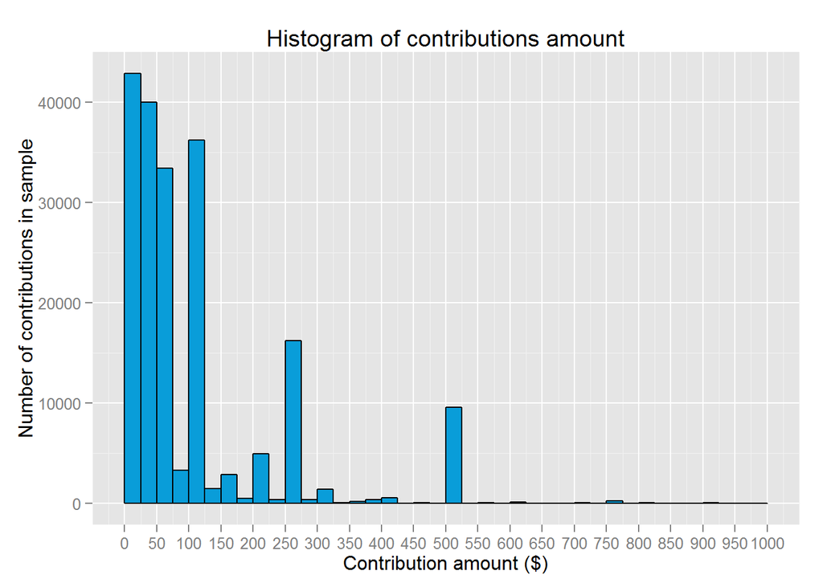

As expected, the number of contributions decreases as the amount increases. Still we can see some high “isolated” bars corresponding to “whole” amounts (like 100$, 200$, 250$, etc…).

I would like to see how much these values are frequent. In order to do it, I will define a variable called “whole_flag” which tells whether each contribution is in one of the following values: 10, 20, 50, 100, 250, 500, 1000, 2000, 2500, 5000.

```r
ma2012$whole_flag <-
  as.factor(ifelse(ma2012$contb_receipt_amt %in%
                     c(10, 20, 50, 100, 250, 500, 1000, 2000, 2500, 5000),
                   "Y",
                   "N"))
table(ma2012$whole_flag)
```

```
##
##      N      Y
## 100467 110836
```

As we can see, more than 50% of the contributions comes from “whole” amounts.

Another variable we expect to influence contributions is the distance from the center of Boston. Let’s see how contributions are distributed respect to the variable *distance*:

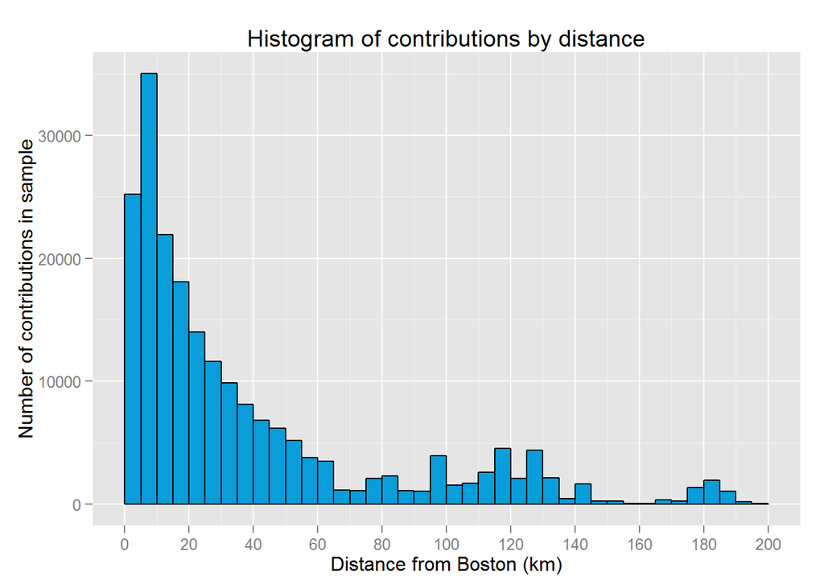

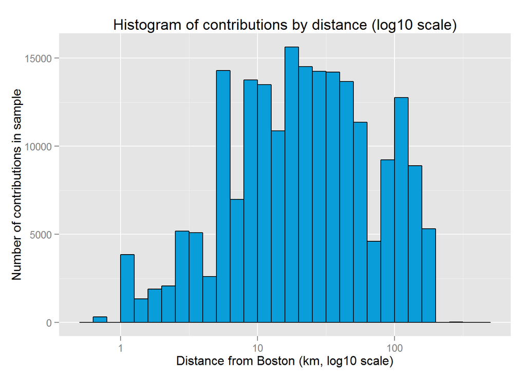

This looks similar to a normal distribution in logarithmic scale. Still it has some spikes, which were already visible in the plot with normal scale (see the higher bars between 100 and 130 km) and are emphasized in logarithmic scale.

We also expect contributions to increase as we get closer to the elections. Let’s see if this is confirmed in our dataset by checking how contributions are distributed with respect to the variable *days_togo*

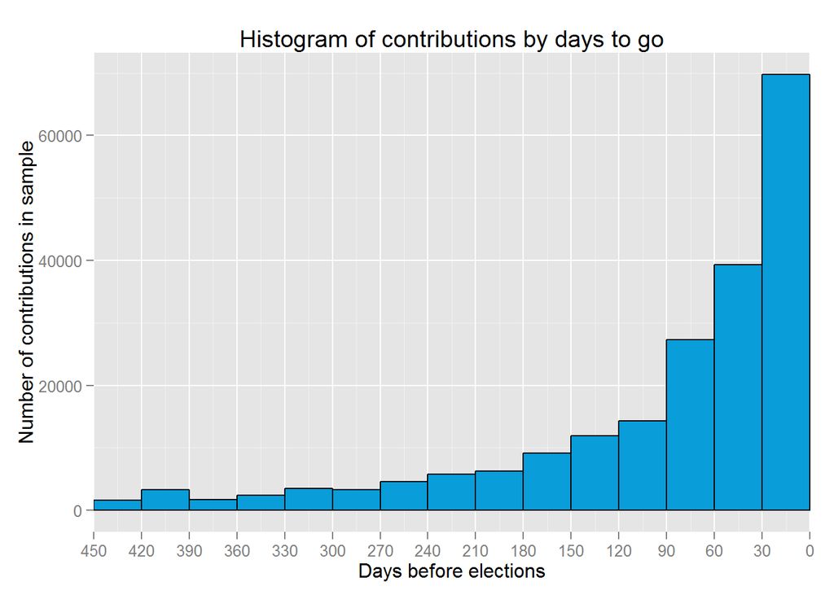

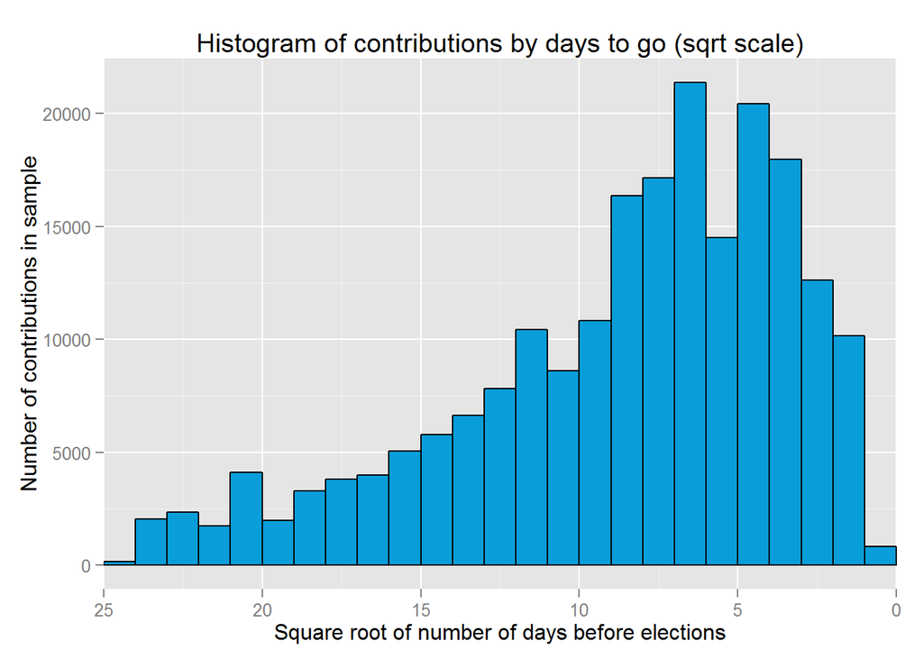

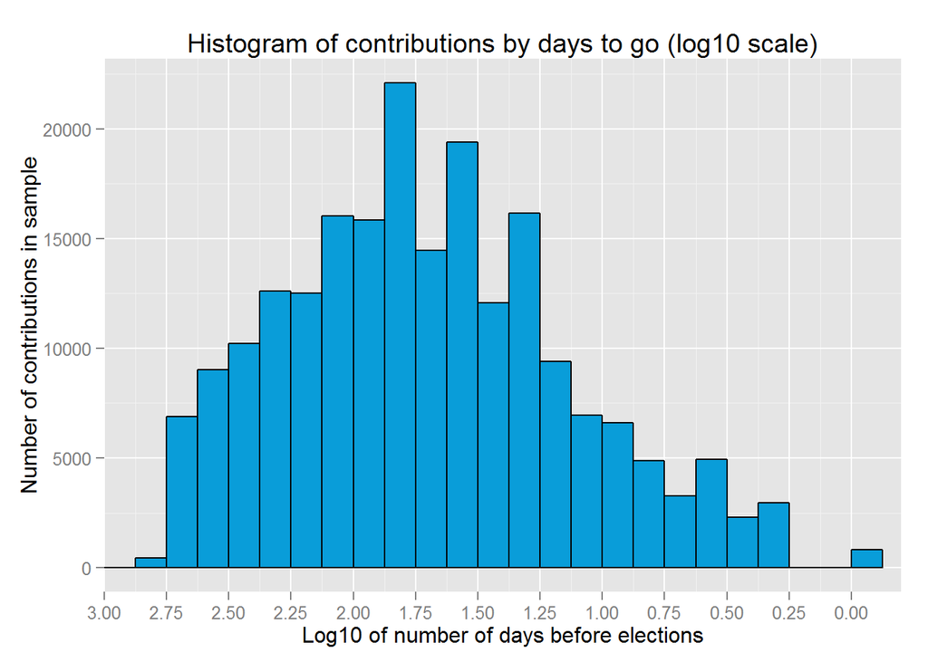

As we can see, the number of contributions increase strongly along the time dimension. In logaritmic scale, the distribution looks similar to a normal one.

# Univariate Analysis

### What is the structure of your dataset?

The original dataset proposed for this analysis comes from the Federal Elections Commission website. The dataset contains data about financial contribution to the 2012 Presidential elections.

I have joined this dataset with another one available in the “zipcode” R package in order to geo-referenciate each row by means of the zip code.

The final dataset is composed by 211.303 observations of 28 variables. Most of these variables were present in either of the original datasets, while some were calculated in order to better analyze the data. None of these variables can really be considered an ordered factor.

## Additional observations

Barack Obama is the candidate having received the majority of contributions, second is Mitt Romney. The Republican Party has many more candidates than any other party.

Democrats have received 79.5% of the total number of contributions and Republicans the 20.3%. Looking at total amounts of contributions, the split is significantly different: Democrats have received the 54.4% of the total amount of contributions, while Republicans have received the 45.3%. This simple statistic already tells us something very clear about the populations that contributed to the fund raising: apparently, the populations supporting the two parties have different behaviours/propensions and the one that supported Republicans is smaller (in Massachusetts), but actually willing to pay much more for supporting its candidates.

Contributions have some highly recurring values, corresponding to “whole” amounts, like 100$, 200$, 250$, etc… More than 50% of the contributions correspond to one of these values.

Number of contributions decrease as the distance from Boston center increases. Nonetheless, there still are isolated higher bars corresponding to high values of distance (well visible in both linear and logarithimc scales). These may be due to bigger towns in Massachusetts. More than 53% of number of contributions (and about 60% of total contribution amount) is located within the first 25 km from the center of Boston.

There is a very clear trend in the number of contributions along the time dimension. The number increases strongly as the elections get nearer.

There are some negative contributions, mostly due (as it appears in the receipt descriptions) to balancing transactions, charge backs, internal transfers.

### What is/are the main feature(s) of interest in your dataset?

The most important features are the amount and number of contributions.

### What other features in the dataset do you think will help support your investigation into your feature(s) of interest?

Additional interesting features are: the date of the transaction (seen as number of days before the elections), the distance of the contributor’s town from Boston, the candidate’s name and party.

### Did you create any new variables from existing variables in the dataset?

I have created some variables in order to allow some analyses on elements that I imagined to be meaningful for analyzing this phenomenon.

- distance - distance of the contributor’s zip code from the center of Boston (identified by the zip code 02116).
- days_togo - number of days between the transaction date and the day of the elections (6 November 2012).
- cand_gender - gender of the candidate
- cand_party - political party of the candidate

### Of the features you investigated, were there any unusual distributions? Did you perform any operations on the data to tidy, adjust, or change the form of the data? If so, why did you do this?

The zipcode of the contributor contained some strange characters (e.g. “*“) and I had to remove it in order to use this field. I had also to cut it to the first five characters.

# Bivariate Plots Section

### Analysis by party

I expect the candidate’s party to be one of the most important features. Let’s start with faceting by party some of the plots from the previous section and see if we can spot some differences.

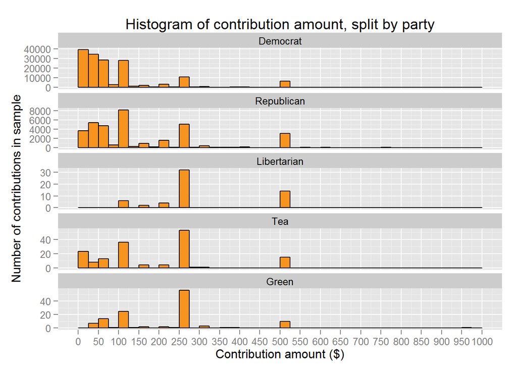

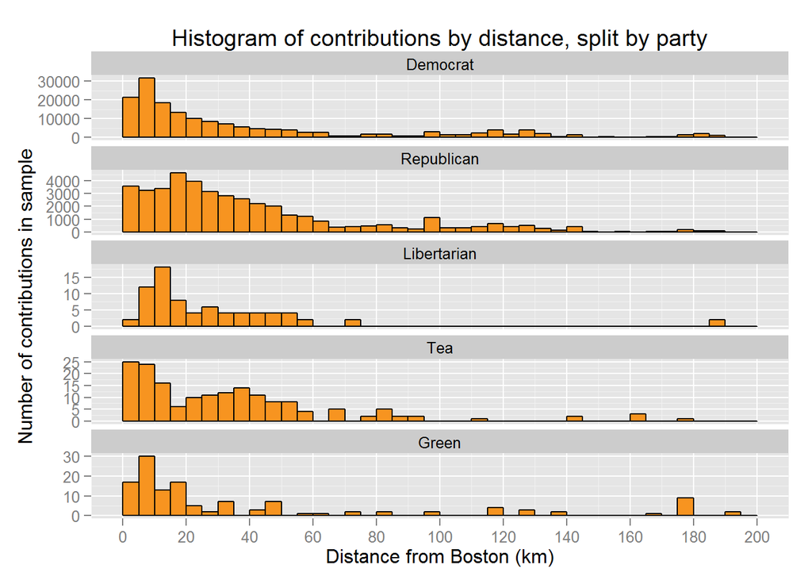

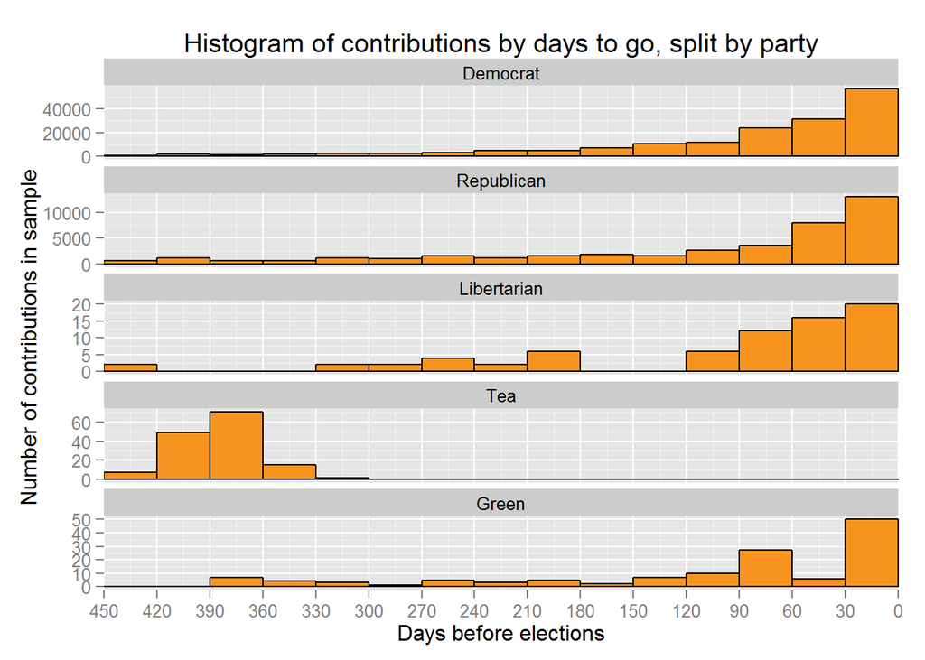

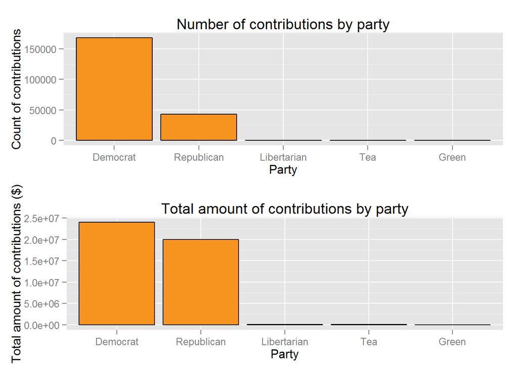

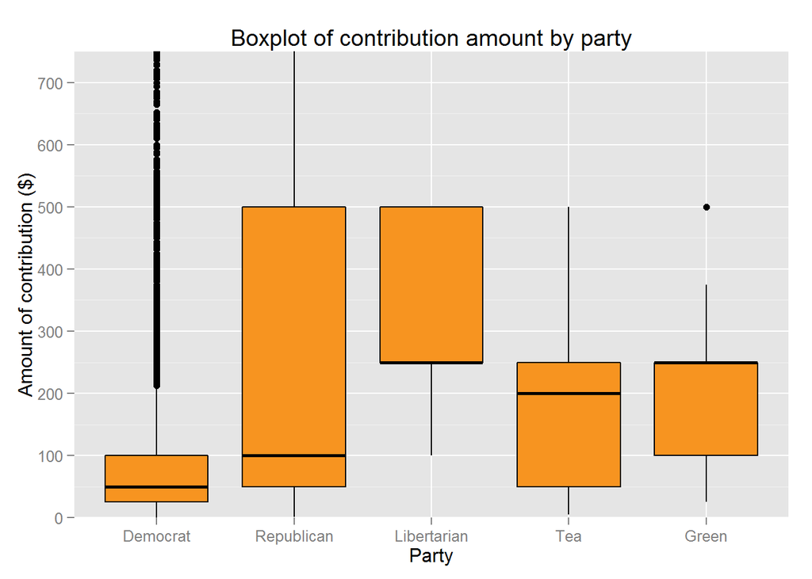

There is a clear difference in the distribution of contribution amounts between the two major parties. Let’s see this difference in numbers:

```r
# Calculation of quartiles and IQRs
by(subset(ma2012, !is.na(ma2012$contb_receipt_amt)
          & ma2012$contb_receipt_amt > 0
          )$contb_receipt_amt,
   subset(ma2012, !is.na(ma2012$contb_receipt_amt)
          & ma2012$contb_receipt_amt > 0
          )$cand_party, summary)
```

```
## subset(ma2012, !is.na(ma2012$contb_receipt_amt) & ma2012$contb_receipt_amt > : Democrat
##     Min.  1st Qu.   Median     Mean  3rd Qu.     Max.
##     0.25    25.00    50.00   146.70   100.00 20000.00
## --------------------------------------------------------
## subset(ma2012, !is.na(ma2012$contb_receipt_amt) & ma2012$contb_receipt_amt > : Republican
##    Min. 1st Qu.  Median    Mean 3rd Qu.    Max.
##     1.0    50.0   100.0   490.7   500.0  7500.0
## --------------------------------------------------------
## subset(ma2012, !is.na(ma2012$contb_receipt_amt) & ma2012$contb_receipt_amt > : Libertarian
##    Min. 1st Qu.  Median    Mean 3rd Qu.    Max.
##   100.0   250.0   250.0   614.5   500.0  2500.0
## --------------------------------------------------------
## subset(ma2012, !is.na(ma2012$contb_receipt_amt) & ma2012$contb_receipt_amt > : Tea
##    Min. 1st Qu.  Median    Mean 3rd Qu.    Max.
##     5.0    50.0   200.0   296.2   250.0  2500.0
## --------------------------------------------------------
## subset(ma2012, !is.na(ma2012$contb_receipt_amt) & ma2012$contb_receipt_amt > : Green
##    Min. 1st Qu.  Median    Mean 3rd Qu.    Max.
##    25.0   100.0   250.0   250.7   250.0  2500.0
```

```r
IQR(subset(ma2012, !is.na(ma2012$contb_receipt_amt)
          & ma2012$contb_receipt_amt > 0
          & cand_party == "Democrat")$contb_receipt_amt, na.rm = FALSE)
```

```
## [1] 75
```

```r
IQR(subset(ma2012, !is.na(ma2012$contb_receipt_amt)
          & ma2012$contb_receipt_amt > 0
          & cand_party == "Republican")$contb_receipt_amt, na.rm = FALSE)
```

```
## [1] 450
```

As we can see, the difference between the two distributions of Democrats and Republicans is impressive. While 75% of contributions for Democrats stands below 100$, the 75% of contributions for Republicans can go up to 500$.

### Analysis of other variables

Let’s see the relationship between amount of contributions and days before the elections. Does the amount increases, dicreases or does not substantially change while the time passes?

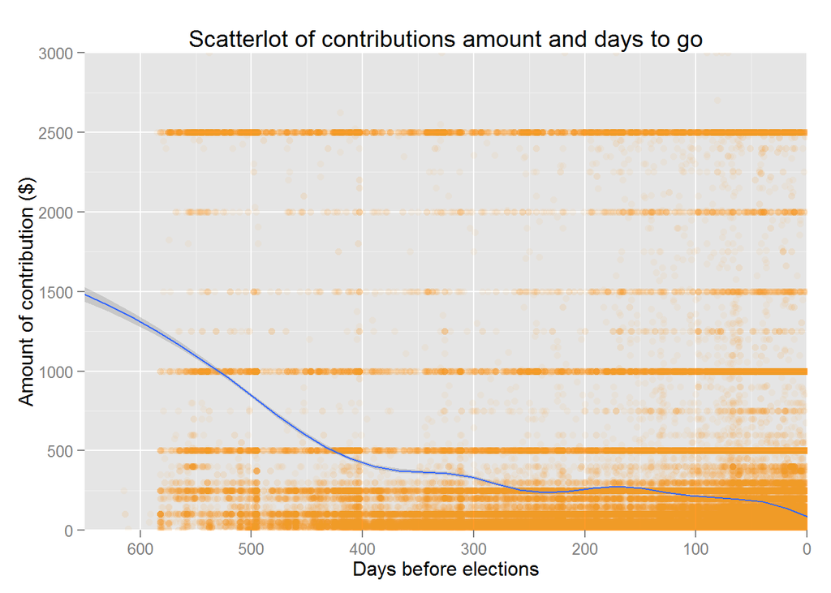

```
##
##  Pearson's product-moment correlation
##
## data:  days_togo and contb_receipt_amt
## t = 115.2314, df = 211301, p-value < 2.2e-16
## alternative hypothesis: true correlation is not equal to 0
## 95 percent confidence interval:
##  0.2391406 0.2471640
## sample estimates:
##       cor
## 0.2431565
```

As we can see, the correlation isn’t strong (0.24). Nonetheless, the smoothing function helps identifying a decreasing trend of the amount of contributions. “Whole” amounts (like 500$, 1000$, 2500$) are still very visible though (see the horizontal lines).

Let’s see now if there’s any relationship between distance from Boston amount and days to go. Can we see if citizens living farer from Boston tend to contribute earlier or later?

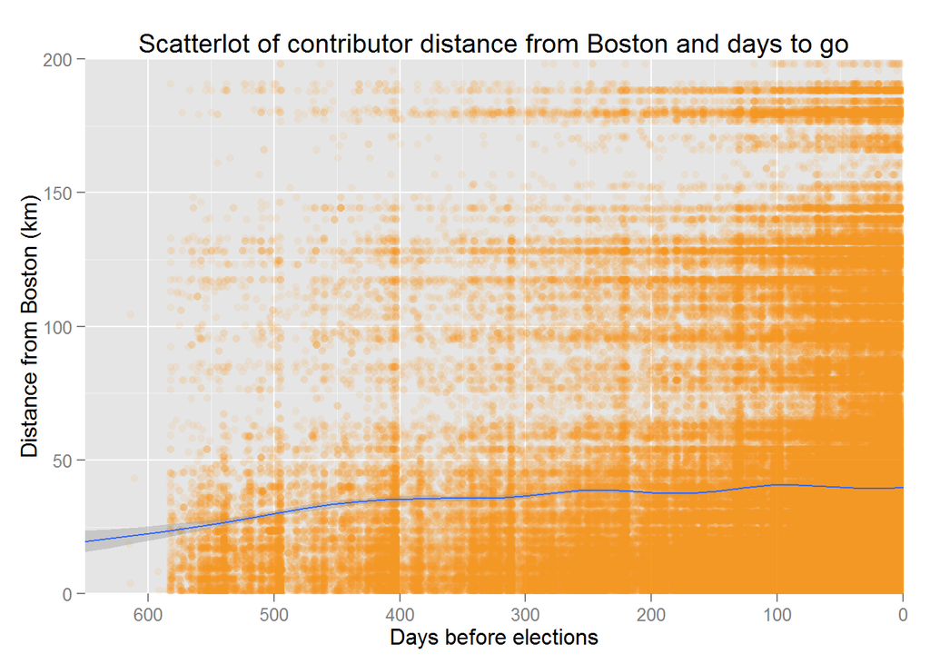

```
##
##  Pearson's product-moment correlation
##
## data:  days_togo and distance
## t = -19.2369, df = 210955, p-value < 2.2e-16
## alternative hypothesis: true correlation is not equal to 0
## 95 percent confidence interval:
##  -0.04610561 -0.03758599
## sample estimates:
##         cor
## -0.04184656
```

Here the correlation is really weak (-0.04). And also from the graph we only can notice some vertical or horizontal patterns: this is a clear sign that the dynamics of the two variables are mostly independent.

Let’s see what happens between distance from Boston and amount of contribution. Maybe citizens that are closer to the Capital city are willing to contribute more?

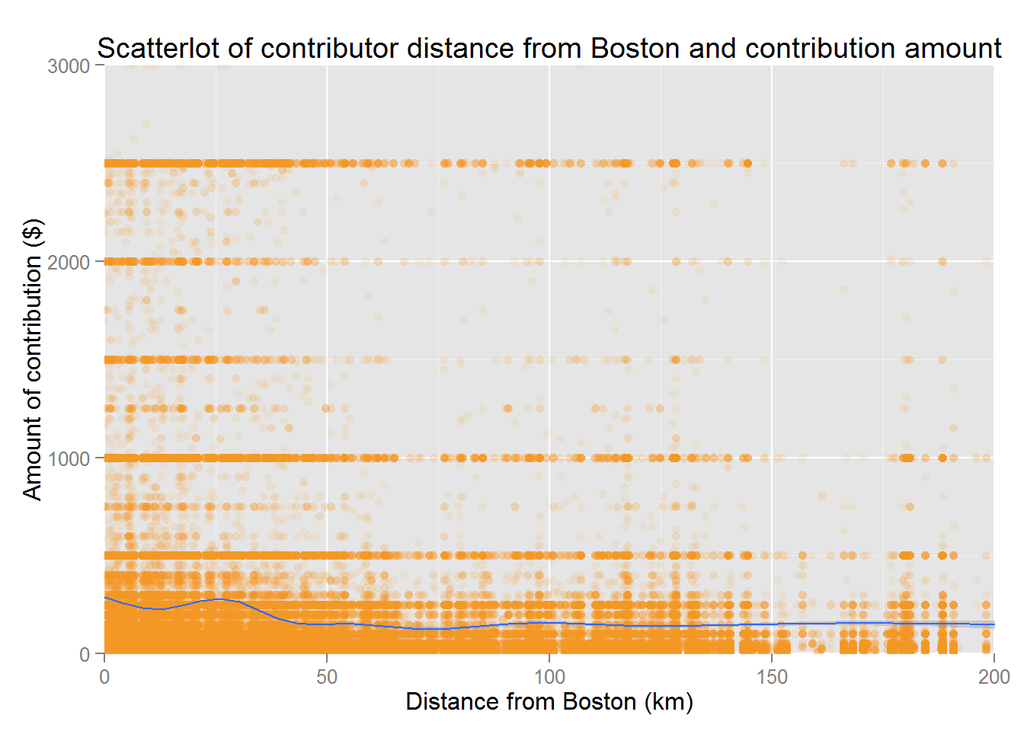

```
##
##  Pearson's product-moment correlation
##
## data:  distance and contb_receipt_amt
## t = -34.0421, df = 210955, p-value < 2.2e-16
## alternative hypothesis: true correlation is not equal to 0
## 95 percent confidence interval:
##  -0.07815750 -0.06966956
## sample estimates:
##         cor
## -0.07391486
```

Also in this case, the correlation is very weak (-0.07) and we can’t spot any relevant trend. Horizontal and vertical patterns are the most evident sign.

Still I am wondering how contributions are concentrated along the distance. For doing this, I will create a factor called *distance_bucket* corresponding to subsequent intervals of distance from Boston (25, 50, 75, 100 km) and then calculate the cumulative percentage of both number and amount of contributions. I will also create a boxplot by party.

```
##    Min. 1st Qu.  Median    Mean 3rd Qu.    Max.    NA's
##   0.000   8.784  20.930  38.900  49.740 341.600     346
```

```
## Source: local data frame [6 x 3]
##
##   distance_bucket cumpercent_contb_num cumpercent_contb_amt
## 1          (0,25]             53.26522             60.31046
## 2         (25,50]             73.58580             79.66615
## 3         (50,75]             80.60132             84.01339
## 4        (75,100]             85.58374             87.70023
## 5       (100,500]             98.44867             96.28409
## 6              NA            100.00000            100.00000
```

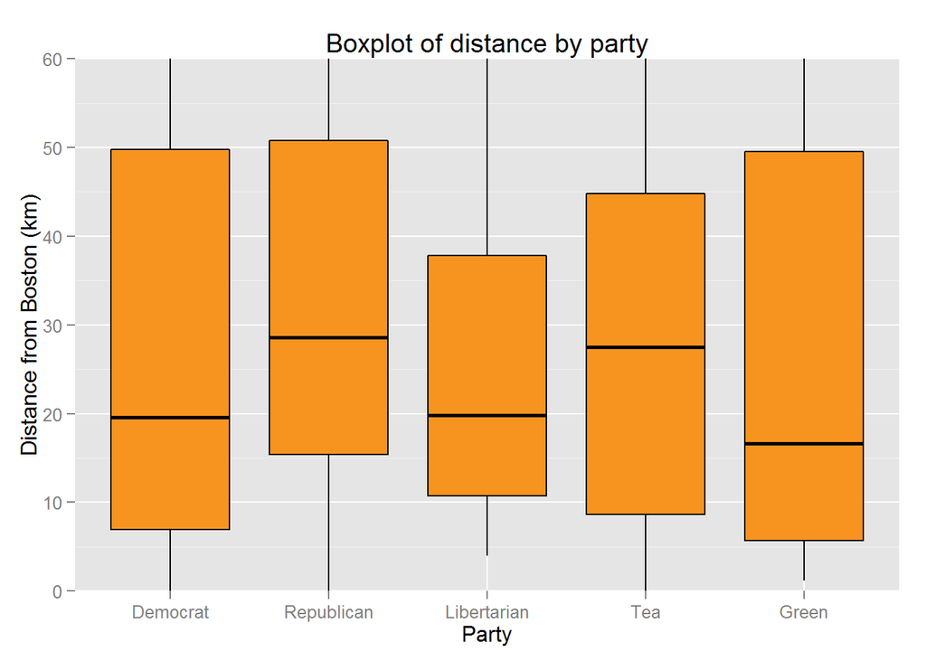

As we can see from the table of cumulative percentages, more than 53% of number of contributions (and about 60% of total contribution amount) is located within the first 25 km from the center of Boston. Moreover, it is interesting to notice in the boxplot how the third quartile is stable on the value of 50 km (especially for th two major parties). On the other hand, Democrats have a considerably lower median (10 km less). This confirms the insight we had from the previous histogram, that is, Democrats have received more contributions in the Boston city area while Republicans were stronger in the surrounding towns.

Let’s see if we can discover some unexpected insights by analyzing the coordinates of the zipcode where the contributor resides.

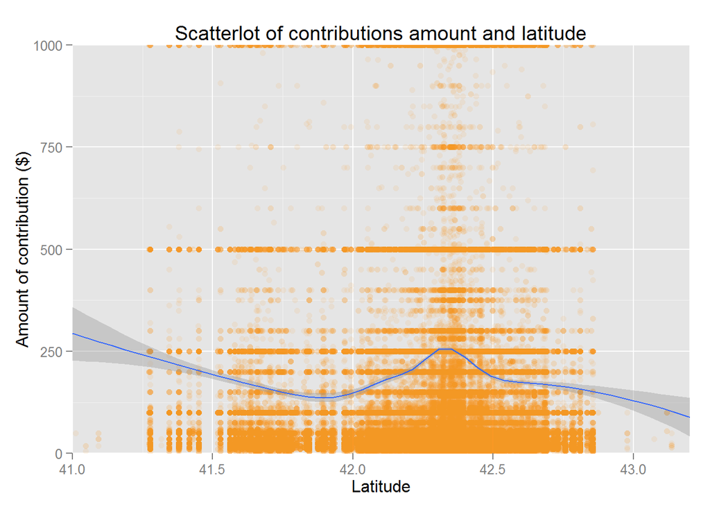

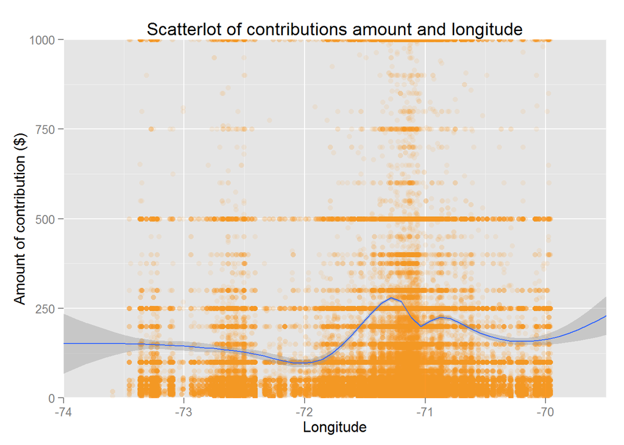

As we can see, the amount of contributions has clear peaks around one place in the map. As we can easily guess, those should be the coordinates where the center of Boston is located. Let’s see if this becomes more evident by using of a scatterplot of latitude and longitude together.

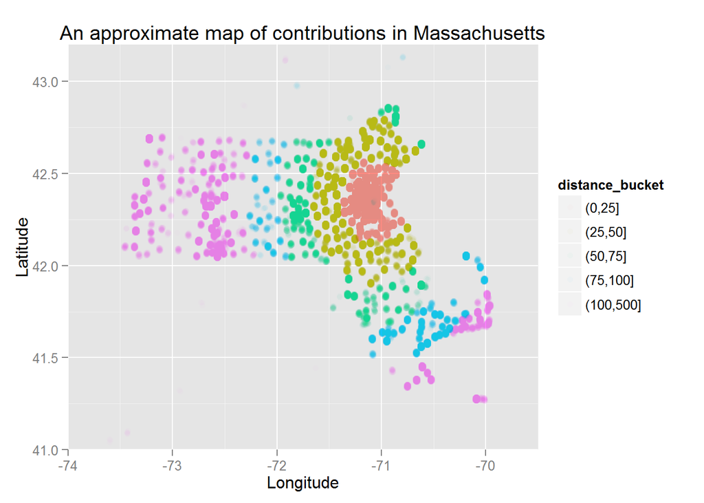

I have coloured the dots according to the *distance bucket* variable in order to highlight the different bands. Let’s remember that more of the 50% of the contributions were located in the first 25 km from Boston (the red dots in the map): I have used some jittering and a value of alpha = 1/40 in order to better highlight this.

# Bivariate Analysis

### Talk about some of the relationships you observed in this part of the investigation. How did the feature(s) of interest vary with other features in the dataset?

Contributions have clear common trends across parties, but also interesting differencies. For example:

- The biggest bucket for Democrats corresponds to small contributions (below 100$), while Republicans have received more bigger contributions. In particular, 75% of contributions for Democrats are below 100$, while for Republicans, 75% of contributions are below 500$.
- Distribution of contributors by distance from Boston: the third quartile is almost the same for Democrats and Republicans (50 km from Boston). It is interesting to notice how instead the two populations are different in the closer distances. The 1st and 2nd quartiles are considerably lower for Democrats than Republicans (both about 10 km less). This highlights a considerable difference between the two populations: contributors for Democrats are more concentrated in the Boston city area, while thos for Republicans are more centered in the surrounding towns.
- Distance from Boston, amount of contribution and number of days before the elections do not seem to have relevant mutual correlation. Still the smoothing function highlights a global decreasing trend of the amount of contributions along the time dimension. Hence: as the elections become nearer, the number of contributions increases, but the amount of each contribution tends to decrease.

### Did you observe any interesting relationships between the other features (not the main feature(s) of interest)?

The amount of contributions has a peak when analyzed against both latitude and longitude. The peak correspond to the coordinates of the Boston city area.

### What was the strongest relationship you found?

The most evident relationship is between party and range of contribution amount. As said above, Democrats have received more contributions than any other party (about 80% of the contributions and 54% of total amount). On the other hand, those contributions were considerably smaller than the contributions received by Republicans. This clearly highlights a difference in the populations of contributors supporting the two parties. If we look at the quartiles for the two populations, this is even more evident:

- For Democrats, 75% of the contributions stand below 100$. The IQR is 75$, hence most of the contributions are contained in a relatively short interval.
- For Republicans, the median is 100$ and the third quartile is 500$. With a IQR of 450$, this distributions is definitely wider than the previous one and composed by lesser, but bigger contributions.

# Multivariate Plots Section

Let’s start with a plot of pairs. This might help in finding some additional insights.

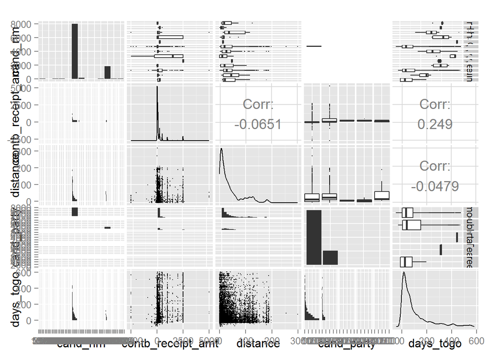

We have seen previously that the time dimension is an important variable. I would like to dig further into this in order to see if we can understand better the dynamics of the fundraising. For example, I would like to recognize some candidates who retired or some candidates who prevailed on other at some specific times.

Let’s start displaying all the candidates on a scatterplot:

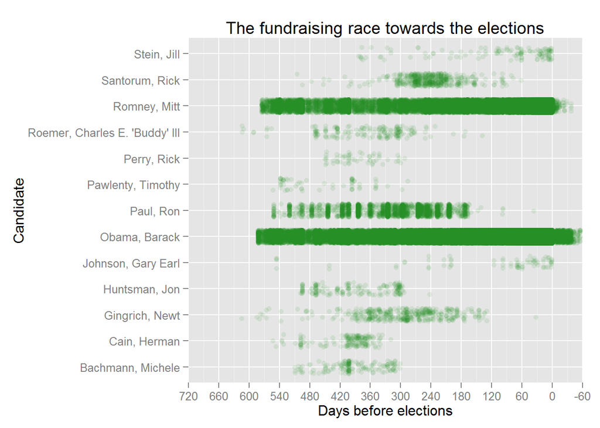

The different stories of each candidate are clearly visible in our data. Only few of them kept receiving contributions until the very end. And surprisingly, Barack Obama received many contributions even after the elections.

Still from the above plot we can’t easily see if and when some candidates prevailed during the race. Let’s see if we can display this using another plot. We will only show Democrats and Republicans as they represent the majority of contributions.

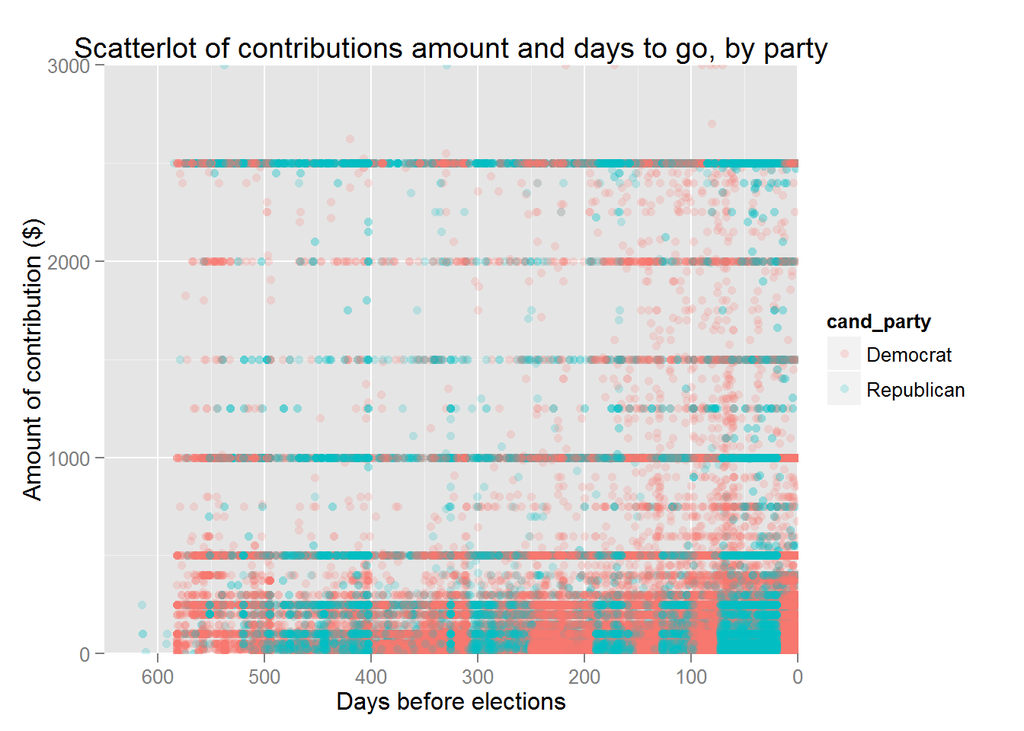

This plot allows to see the different phases of the campaign. See how the two colors alternatively overcome each other or how the bar of 2500$ becomes almost completely blue (Republicans) between about 75 and 25 days before the elections.

What is still unclear from the above plot is the trend of contribution amount of the two parties. We know that Republcans have received in general bigger contributions. But has it always been like that over time? Or perhaps this behavior appeared only at last? Let’s see this by applying a smoothing function to the preious plot’s data.

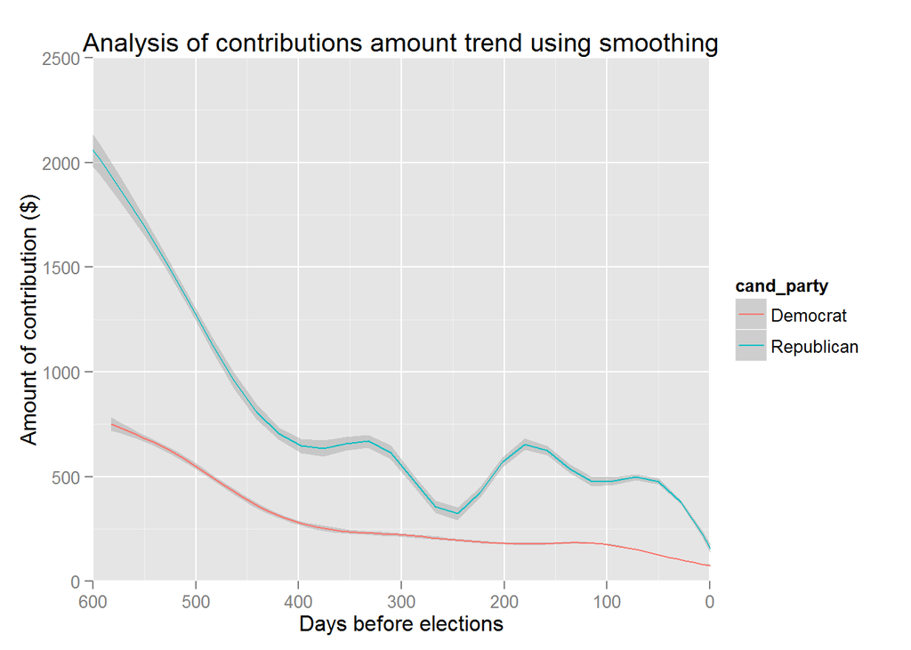

As we can see from the above plot, the average amount of contributions for Republicans was always higher than Democrats. Also, the trend of the amounts for Democrats was much more stable, while Republicans had some up and downs.

Another information I would like to explore better is the location of contributor. We already know that most (more than 50%) of contributions came from the first 25 km from Boston. But we would like to understand better all the dimensions of this phenomenon. Let’s create two maps, displaying in one the total amount of contributions and in the other the average amount by location.

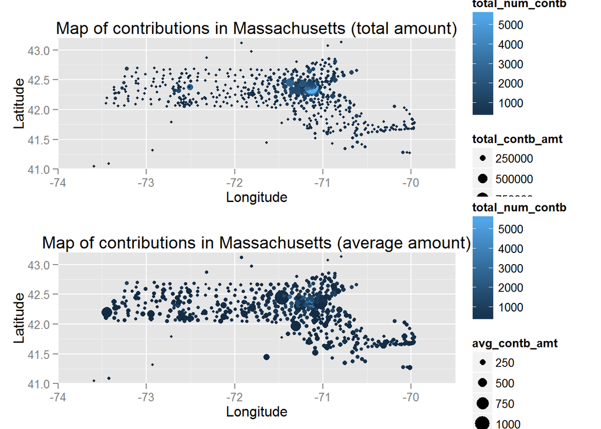

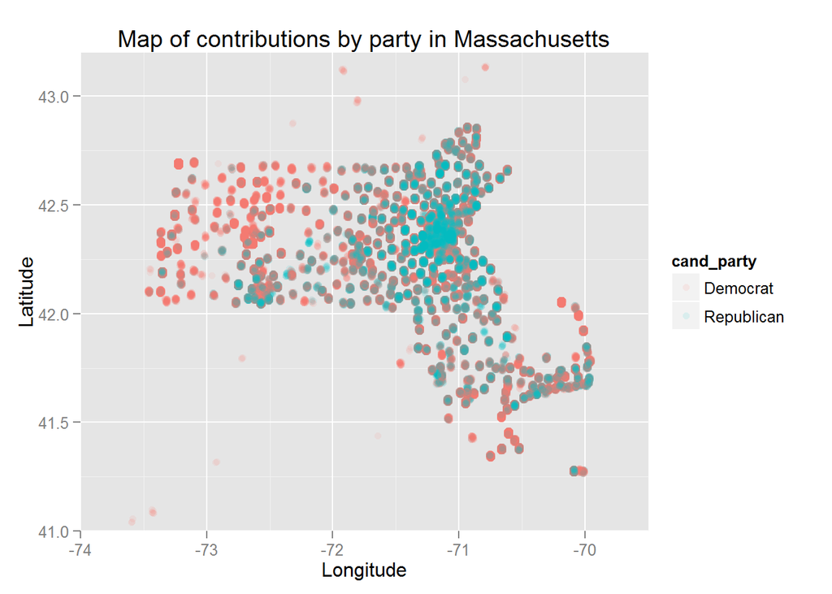

From the two upper plots we can see that while the total amount is concentrated in the Boston area, the *average* amount has some high values also in the areas that are distant from Boston.

# Multivariate Analysis

### Were there any interesting or surprising interactions between features?

- By looking at the “Scatterlot of contributions amount and days to go, by party”,it is interesting to see how the fundraising has had alternating phases, where the two main parties have prevailed each other in different times. For deeper political analyses, it might be intriguing matching this trend with actual events such as conventions, public speeches, etc…

### OPTIONAL: Did you create any models with your dataset? Discuss the strengths and limitations of your model.

# Final Plots and Summary

### Plot One

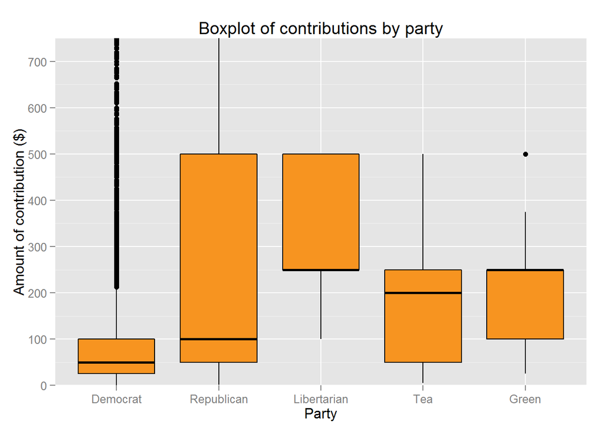

### Description One

We know from previous results that contributions received by Democrats in Massachusetts are greater both in term of number and total amount. Nonetheless, thanks to this plot, it is possible to understand how the two major parties are funded. Democrats have received more small contributions, while Republicans have received less, but significantly bigger, contributions.

### Plot Two

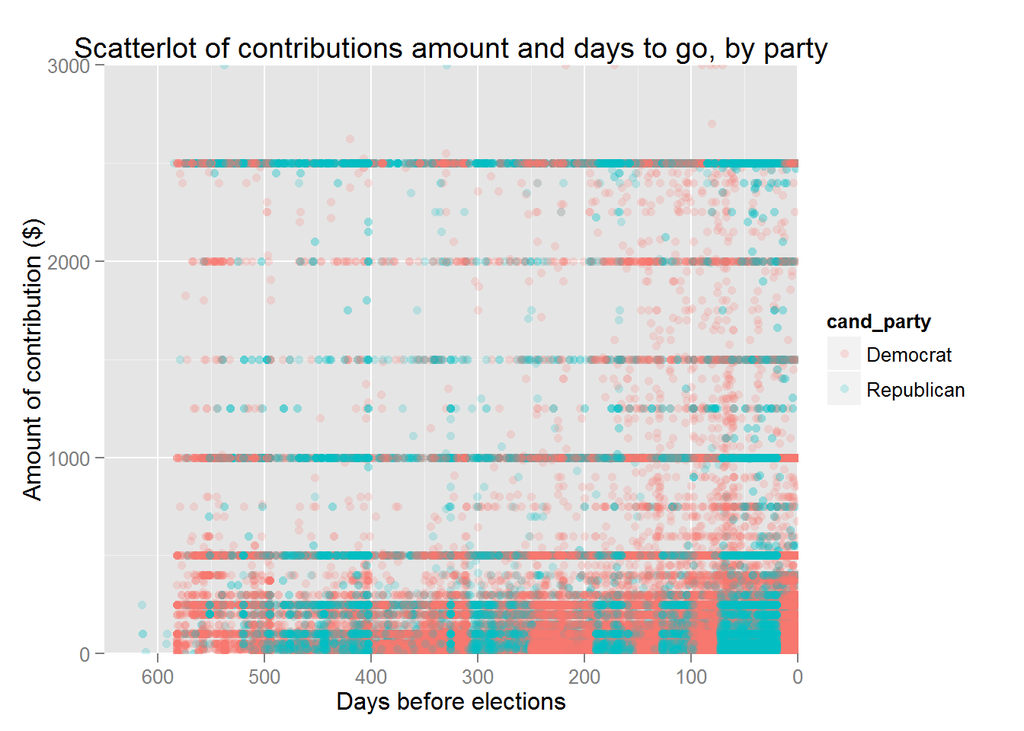

### Description Two

This plot displayes contributions in terms of submission date and amount. The two colors represent the two major parties. As mentioned above, this plot helps identifying alternate phases in the fundraising for the two major parties. This kind of insights could be related to information related to external events in order to understand how they influence the fundraising phenomenon.

### Plot Three

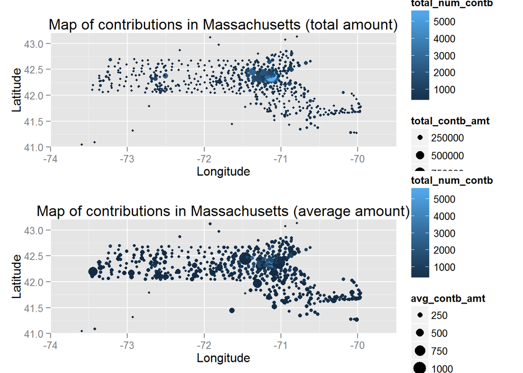

### Description Three

Here are two maps of the State of Massachusetts, where each point represents the contributions for that location. In the upper plot the point size corresponds to the total amount of contributions, while in the lower plot the size stands for the average amount. As we can see, while a lot of contributions came from the closer Boston area, actually the average amount is less concentrated.

# Reflection

The dynamics of the fundraising campaigns appear to be influenced by several factors.

- The time to the elections has clearly an impact. The number of contributions raises very quickly as the elections get close. At the same time, those increasing (in number) contributions become smaller as the time passes. Apparently, bigger contributions (perhaps from companies or richer individuals) happen initially (as a sort of kick-off of the campaigns) and the people’s contributions arises at the end of the campaigns.
- Geography (and demographics) is another important element. Some parties are stronger than other within certain social classes and consequently more contributions may come from specific towns/locations where such classes are more concentrated. Might be interesting to compare this trend with the average income of each town, to see for example if every location contributes the same (compared to the average income), or if there are some towns where people is actually contributing more, not only in absolute terms, but also in comparison to the average income. Such results could reveal interesting insights about the people’s engagement with politics.
- Political and/or social events have impacts on the contributions and may cause parties to receive alternatively more funds within certain periods. Analyzing this aspect more in depth could lead to even predictive results, which might eventually lead to be able to foresee the impact (in terms of contributions) of possible actions that the candidate or the party may want to take during the political campaign.